# netflix_original_로버스트회귀

## 데이터 정의(성공,실패군집)

```r
rm(list=ls())

library(readxl) # readxl 패키지로 엑셀을 읽을 수 있게 해줌
netflix <- read_excel('netflix_original_종합_수정(sum)_(정량화보함).xlsx') # 넷플릭스 오리지널 엑셀데이터를 읽어옴
```

```
* `` -> ...1
```

결과값의 차이를 확인해 보기 위해 종합데이터, 드라마 데이터, 영화 데이터의 회귀를 각각 돌려보았습니다

### 종합 데이터

```r
netflix_original <- netflix
netflix_original <- netflix_original[,c(9,15,18,32:40)] # 엑셀에서 9,15,18 과 32~40번째 열을 가져오는 것.
netflix_original <- na.omit(netflix_original) # 어떤 결측치라도 있으면 행을 제거하고 남은 데이터를 반환
netflix_original[, 4:12] <- lapply(netflix_original[, 4:12], factor) # 위에서 뽑은 12개 열중 4~12열을 계산을 편하게 만들어주고 factor 형태로 만들어줌
netflix_original[, 1:3] <- lapply(netflix_original[, 1:3], as.numeric) # Mean_Length, Director_max_award, All_rating (1~3열) 항목을 숫자형으로 변환
```

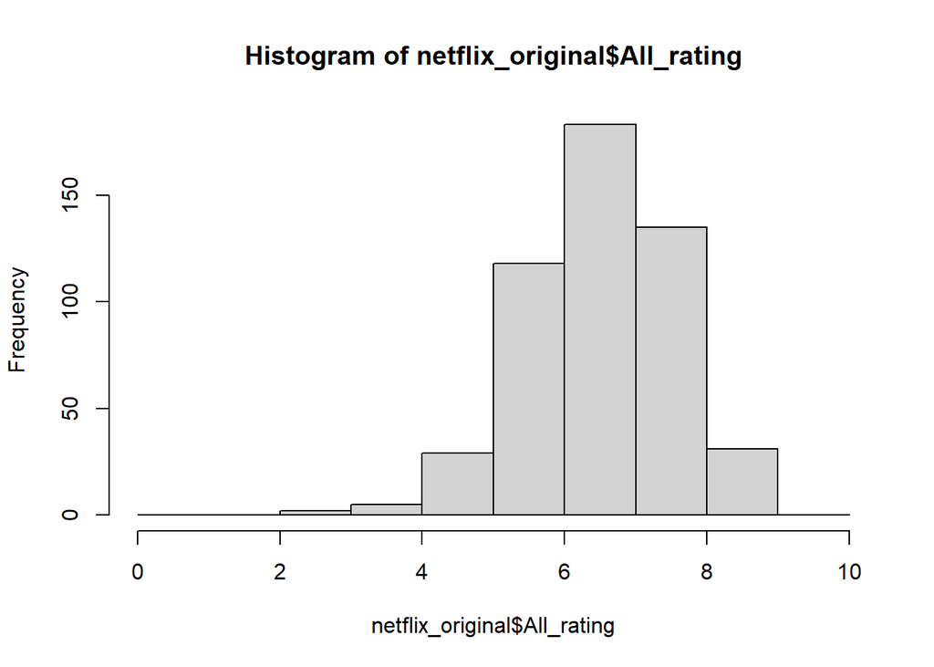

```r
hist(netflix_original$All_rating, seq(0,10)) # 6 점을 기준으로 성공 실패 자름
```

```r
median(netflix_original$All_rating)
```

```
[1] 6.5
```

```r
quantile(as.integer(netflix_original$All_rating))
```

```
  0%  25%  50%  75% 100%
   2    5    6    7    8
```

```r
# 성공 실패 나누기
netflix_original_success <- netflix_original[netflix_original$All_rating>=6.5,]
netflix_original_failure <- netflix_original[netflix_original$All_rating<6.5,]
```

### 드라마 데이터

드라마 데이터와 영화 데이터도 위와 같은 방식인데, 행의 차이만 있음.

드라마와 영화데이터를 나눈 기준은 seasons 항목이 공백이면 영화, 값이 있으면 드라마로 분류하여 분석하였음.

```r
netflix_drama <- netflix[1:170,]
netflix_drama <- netflix_drama[,c(9,15,18,32:40)]
netflix_drama <- na.omit(netflix_drama)
netflix_drama[, 4:12] <- lapply(netflix_drama[, 4:12], factor)
netflix_drama[, 1:3] <- lapply(netflix_drama[, 1:3], as.numeric)
```

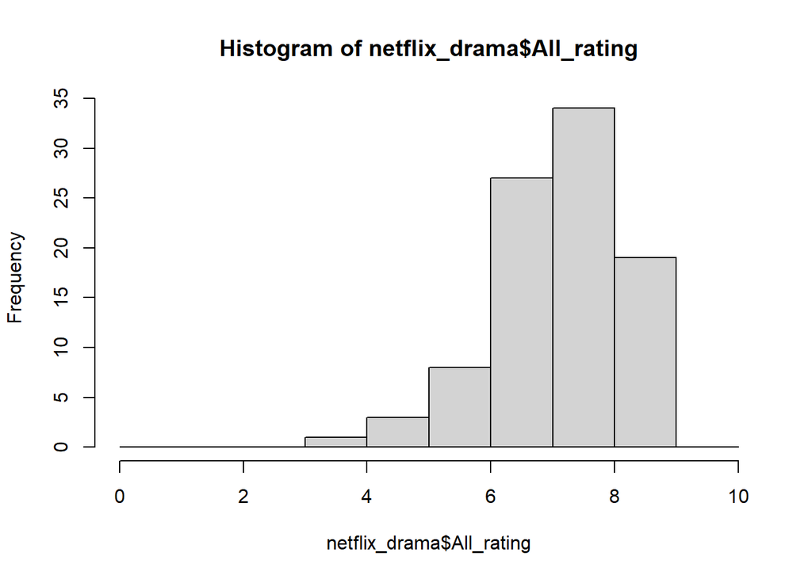

```r
hist(netflix_drama$All_rating, seq(0,10)) # 7점을 기준으로 성공 실패 자름
```

```r
median(netflix_drama$All_rating)
```

```
[1] 7.35
```

```r
quantile(as.integer(netflix_drama$All_rating))
```

```
  0%  25%  50%  75% 100%
3.00 6.00 7.00 7.25 8.00
```

```r
# 성공 실패 나누기
netflix_drama_success <- netflix_drama[netflix_drama$All_rating>=7.35,]
netflix_drama_failure <- netflix_drama[netflix_drama$All_rating<7.35,]
```

### 영화 데이터

```r
netflix_movie <- netflix[171:589,]
netflix_movie <- netflix_movie[,c(9,15,18,32:40)]
netflix_movie <- na.omit(netflix_movie)
netflix_movie[, 4:12] <- lapply(netflix_movie[, 4:12], factor)
netflix_movie[, 1:3] <- lapply(netflix_movie[, 1:3], as.numeric)
```

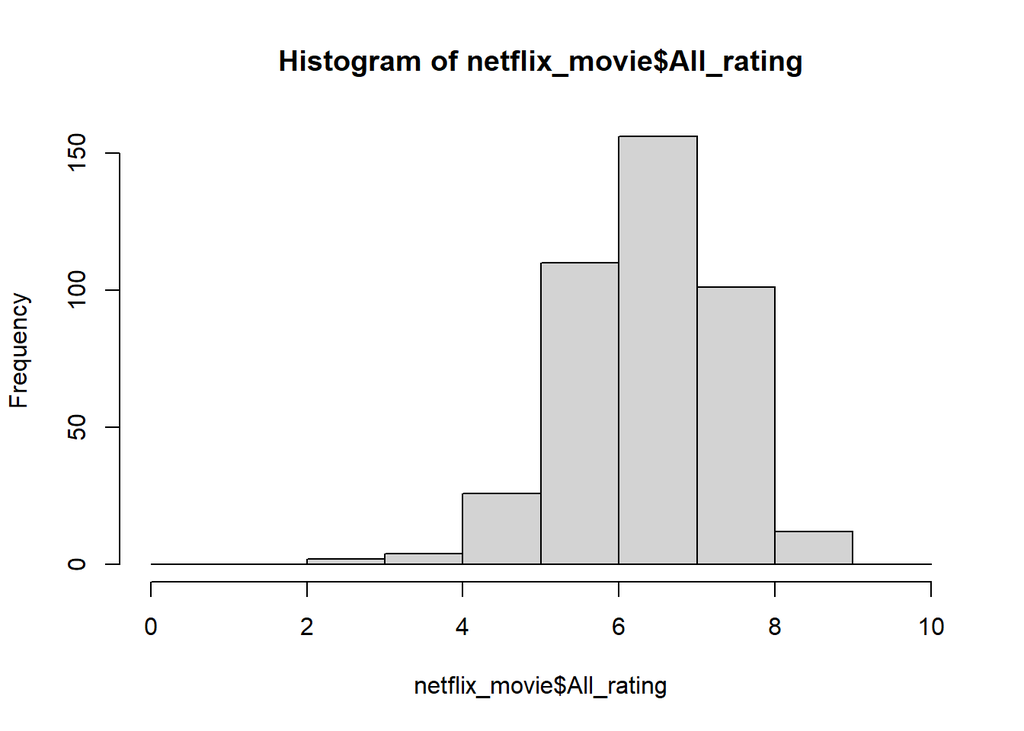

```r
hist(netflix_movie$All_rating, seq(0,10)) # 6점을 기준으로 성공 실패 자름
```

```r
median(netflix_movie$All_rating)
```

```
[1] 6.4
```

```r
quantile(as.integer(netflix_movie$All_rating))
```

```
  0%  25%  50%  75% 100%
   2    5    6    7    8
```

```r
# 성공 실패 나누기
netflix_movie_success <- netflix_movie[netflix_movie$All_rating>=6.4,]
netflix_movie_failure <- netflix_movie[netflix_movie$All_rating<6.4,]
```

## 데이터 시각화

ggplot2 는 데이터를 시각화하기 위한 패키지

넷플릭스 오리지널을 데이터로 사용하고 미학요소인 aes로 x축을 년도, y축을 전체평점으로 정의한다

geom_boxplot을 이용하여 박스그래프 그림

outlier.colour = ‘red’ 로 이상치의 색상을 빨간색으로 표현되게 하였다.

xlab: x축 제목, ylab: y축제목, labs: 범례

위의 방식으로 처음 선정한 factor(제작년도, 관람등급, 유해한주제(정도), 선정성, 폭력성, profanity(욕설), 무서움, 마약, Immatatable)를 x축으로 평점을 y축으로 하여 박스플롯형태로 시각화 한다.

### 년도

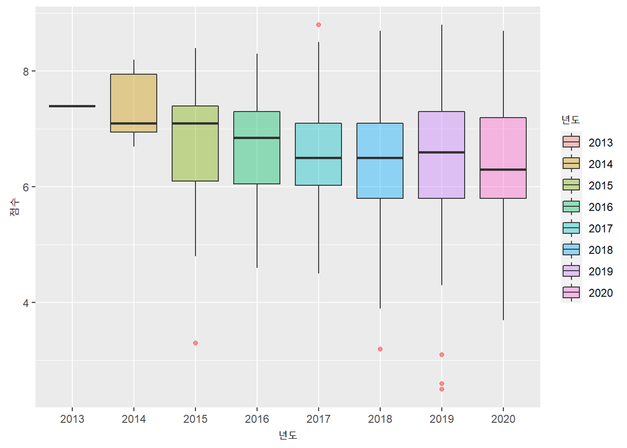

```r
library(ggplot2)
ggplot(netflix_original,aes(x=as.factor(Year),y=All_rating))+
  geom_boxplot(aes(fill=as.factor(Year)),outlier.colour = 'red',alpha=I(0.4))+
  xlab("년도") + ylab("점수") + labs(fill = "년도")
```

### Age

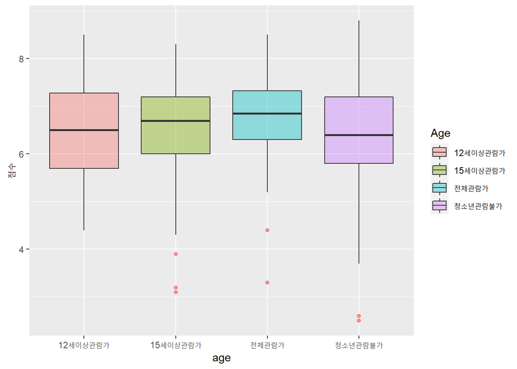

```r
ggplot(netflix_original,aes(x=as.factor(Age),y=All_rating))+
  geom_boxplot(aes(fill=as.factor(Age)),outlier.colour = 'red',alpha=I(0.4))+
  xlab("age") + ylab("점수") + labs(fill = "Age")
```

### Harmful_themes

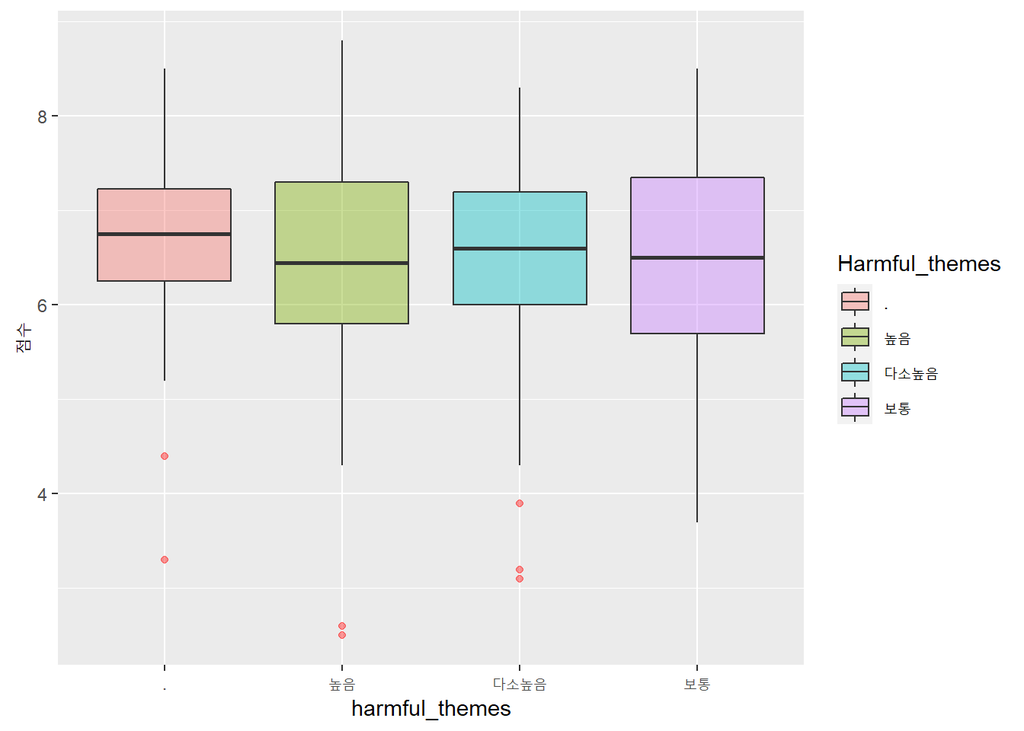

```r
ggplot(netflix_original,aes(x=as.factor(Harmful_themes),y=All_rating))+
  geom_boxplot(aes(fill=as.factor(Harmful_themes)),outlier.colour = 'red',alpha=I(0.4))+
  xlab("harmful_themes") + ylab("점수") + labs(fill = "Harmful_themes")
```

### Lewdness

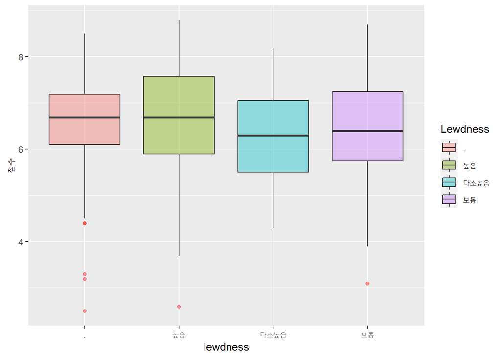

```r
ggplot(netflix_original,aes(x=as.factor(Lewdness),y=All_rating))+
  geom_boxplot(aes(fill=as.factor(Lewdness)),outlier.colour = 'red',alpha=I(0.4))+
  xlab("lewdness") + ylab("점수") + labs(fill = "Lewdness")
```

### Violence

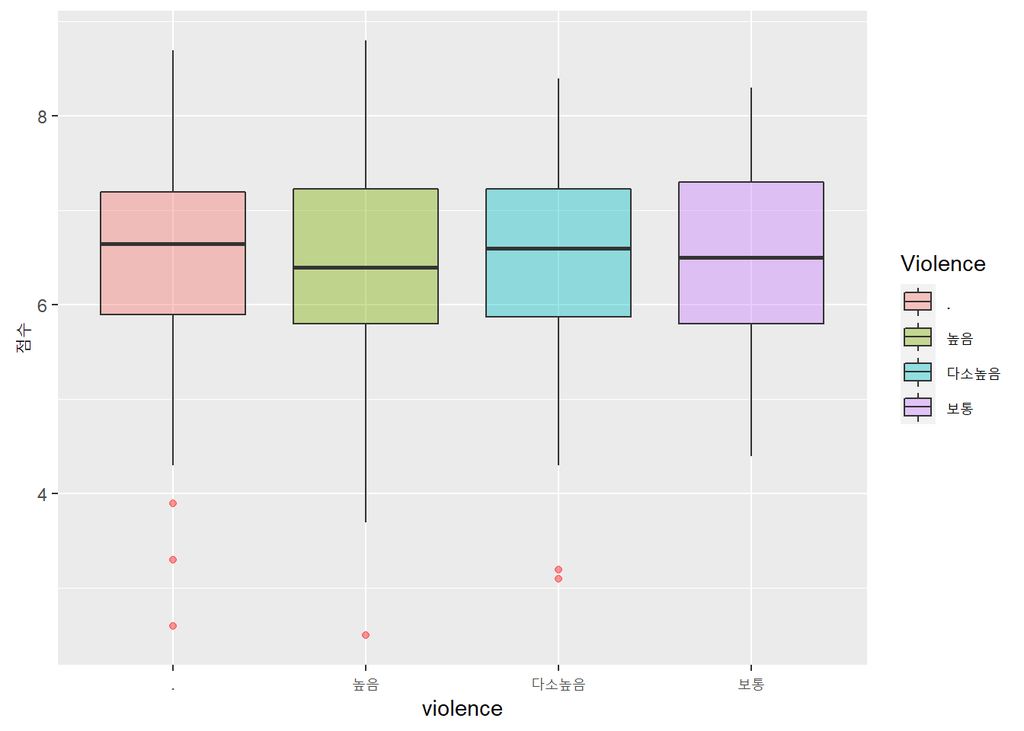

```r
ggplot(netflix_original,aes(x=as.factor(Violence),y=All_rating))+
  geom_boxplot(aes(fill=as.factor(Violence)),outlier.colour = 'red',alpha=I(0.4))+
  xlab("violence") + ylab("점수") + labs(fill = "Violence")
```

### Profanity

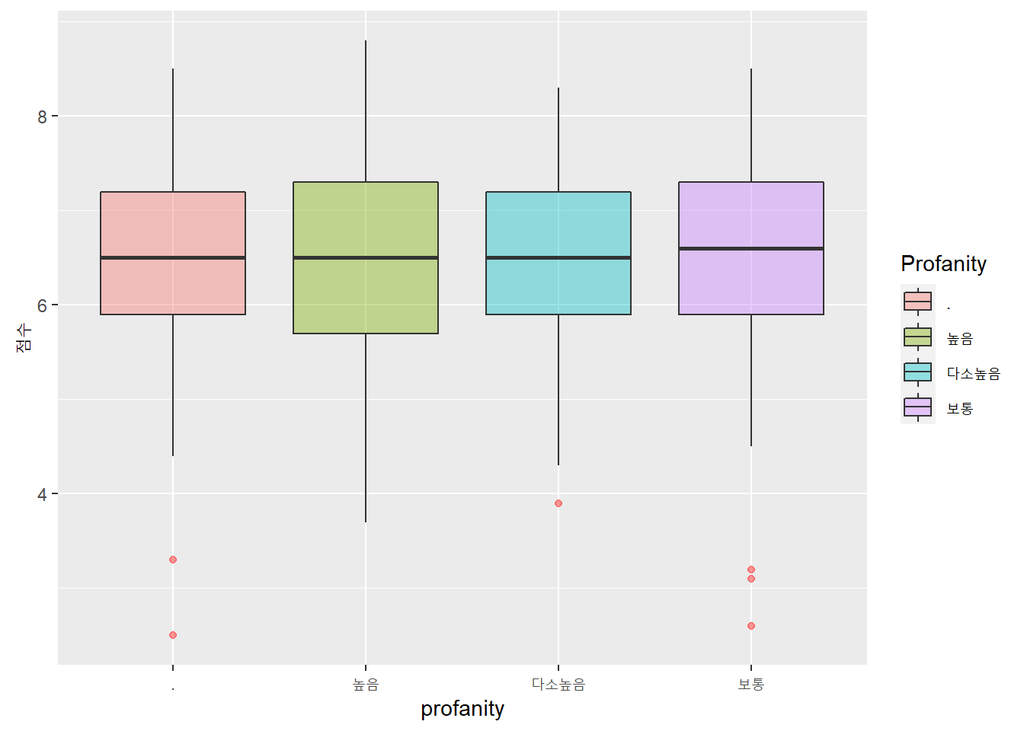

```r
ggplot(netflix_original,aes(x=as.factor(Profanity),y=All_rating))+
  geom_boxplot(aes(fill=as.factor(Profanity)),outlier.colour = 'red',alpha=I(0.4))+
  xlab("profanity") + ylab("점수") + labs(fill = "Profanity")
```

### Fear

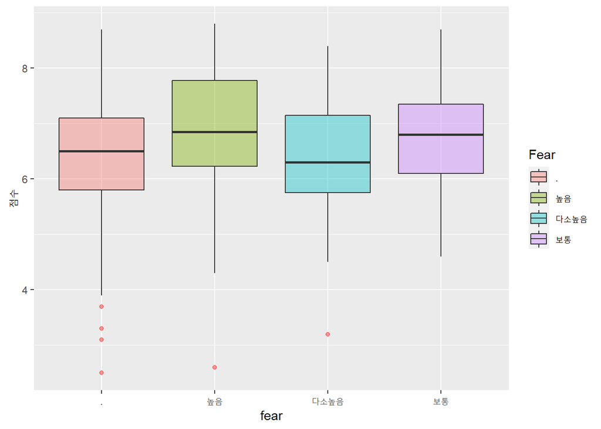

```r
ggplot(netflix_original,aes(x=as.factor(Fear),y=All_rating))+
  geom_boxplot(aes(fill=as.factor(Fear)),outlier.colour = 'red',alpha=I(0.4))+
  xlab("fear") + ylab("점수") + labs(fill = "Fear")
```

### Drugs

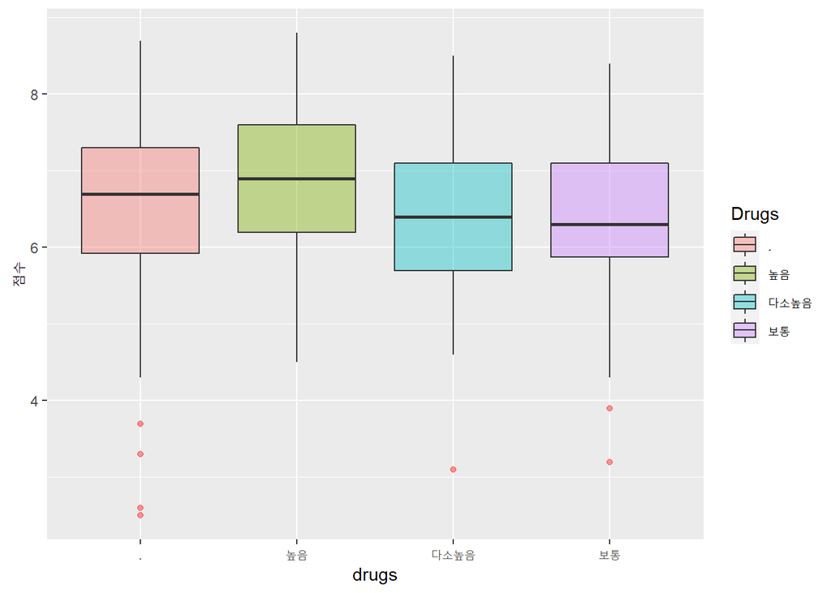

```r
ggplot(netflix_original,aes(x=as.factor(Drugs),y=All_rating))+
  geom_boxplot(aes(fill=as.factor(Drugs)),outlier.colour = 'red',alpha=I(0.4))+
  xlab("drugs") + ylab("점수") + labs(fill = "Drugs")
```

### Immatatable

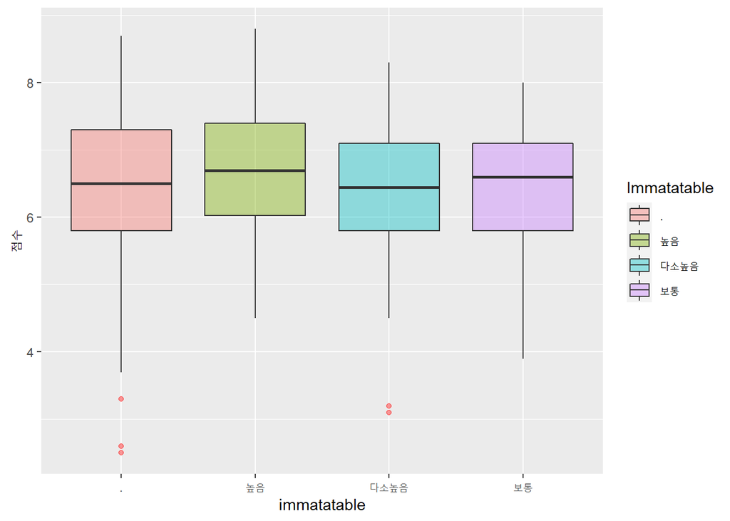

```r
ggplot(netflix_original,aes(x=as.factor(Immatatable),y=All_rating))+
  geom_boxplot(aes(fill=as.factor(Immatatable)),outlier.colour = 'red',alpha=I(0.4))+
  xlab("immatatable") + ylab("점수") + labs(fill = "Immatatable")
```